# Under- and Over-representation at the Museum of Modern Art

Aviva Foster

1 March 2024

### Background

The Museum of Modern Art (often referred to as the MoMA) in New York City is a museum dedicated to modern and contemporary art, founded in 1929. However, despite its modern focus, the museum has come under fire for controversial political moves before, including the withholding of funding for a project which opposed the Vietnam War in the 1960s. Another controversial aspect of the MoMA is its lack of representation in the art and artists it features.

### Demographics: Nationality

One problematic aspect of the MoMA is the demographics of the artists it features in its collections. The MoMA holds art made by artists belonging to 125 unique nationalities, but as you can see in the graph depicted below, only 9 countries have more than 200 artists represented in the collection. Additionally, out of those 9, only one country (Japan) is from a place other than Europe and North America, and the United States is extremely overrepresented, with nearly 5,000 individual artists, whereas every other country has under 1,000. This bar chart clearly shows this disparity by comparing the number of artists of each nationality side-by-side.

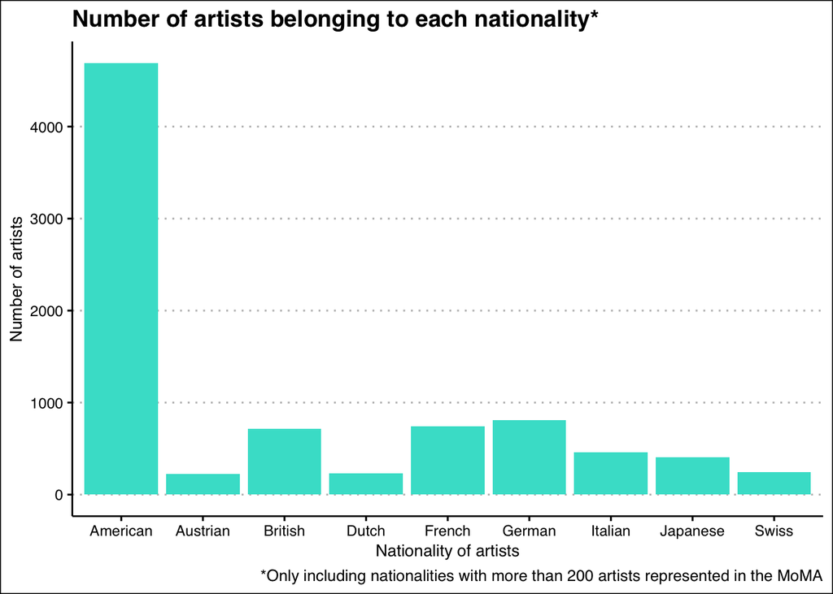

```r
ggplot(na.omit(more_artists), aes(x = Nationality)) +
  geom_bar(fill = "turquoise") +
  labs(y = "Number of artists", x = "Nationality of artists", title = "Number of artists belonging to each nationality*", caption = "*Only including nationalities with more than 200 artists represented in the MoMA") +
  theme_clean()
```

### Demographics: Gender

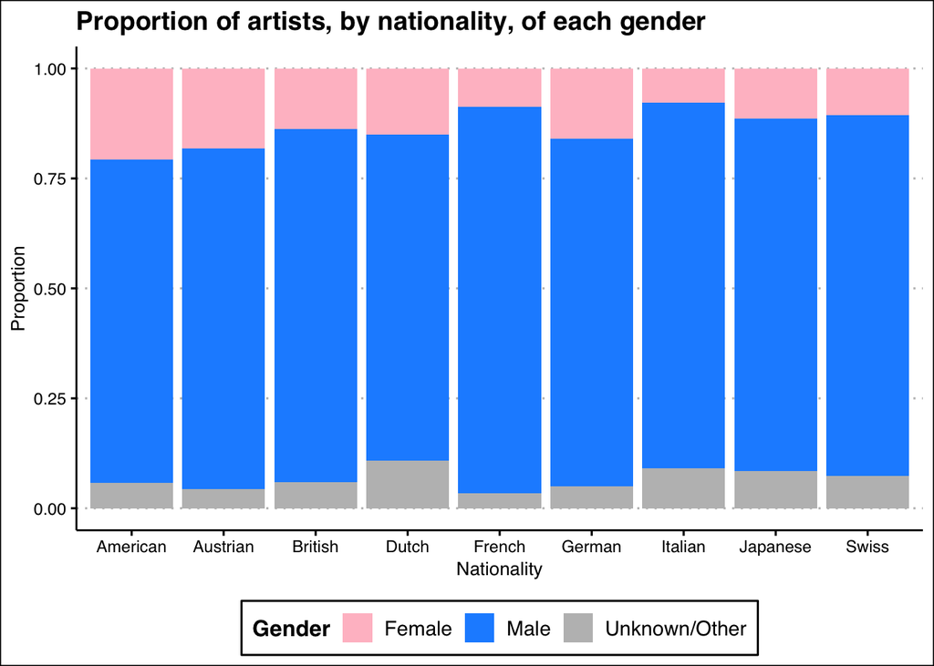

```r
ggplot(data = na.omit(more_artists), aes(x = Nationality)) +
  geom_bar(aes(fill = Gender), position = "fill") + labs(y = "Proportion", x = "Nationality",title = "Proportion of artists, by nationality, of each gender") +
  scale_fill_manual(values = c("pink", "dodgerblue", "gray")) +
  theme_clean() +
  theme(legend.position = "bottom")
```

### Conclusion

The Museum of Modern Art, while claiming to focus on the modern era, does not represent a modern population. American and European men are strongly overrepresented among the artists featured in their collection, and this problem has not been corrected in the nearly 100 years of the museum’s history. Although there are many great works of art at the MoMA, the museum still leaves much to be desired for the modern patron.

This data was provided by the Museum of Modern Art for the public domain, drawn from [this online dataset](https://www.kaggle.com/datasets/momanyc/museum-collection?select=artworks.csv). The dataset includes information about 15,091 individual artists, including their names, nationalities, genders, and birth and death years; it also contains data on 130,262 individual works of art (which I did not use in this analysis).